# Project 4

Brad Harbans

5/2/2021

## Introduction

For this assignment we have given two sets of email messages. One set is known to be spam and another set is known to be “ham,” a legitimate message. I have downloaded two files from the example corpus https://spamassassin.apache.org/old/publiccorpus/.[^1] I have downloaded the files named `20021010_easy_ham.tar.bz2` and `20021010_spam.tar.bz2` containg sample ham and spam messages respectively. I have also made my chosen files available on [github](https://github.com/bharbans/DATA607_P4/tree/main/corpus).

## Import Data

### Download and Unzip Files

```r
hamURL <- 'https://spamassassin.apache.org/old/publiccorpus/20021010_easy_ham.tar.bz2'
spamURL <- 'https://spamassassin.apache.org/old/publiccorpus/20021010_spam.tar.bz2'

download.file(hamURL,"corpus/20021010_easy_ham.tar.bz2")
download.file(spamURL,"corpus/20021010_spam.tar.bz2")

untar("corpus/20021010_easy_ham.tar.bz2", exdir = "corpus/")
untar("corpus/20021010_spam.tar.bz2", exdir = "corpus/")
```

### Text Mining Package

I will be using the `tm`, Text Mining Package, in R to import the spam and ham data sets and to do some analysis.

```r
library(tm)
```

### Import Data from Files and Export to Data Frame

The data sets have been imported as as `Corpus` objects. I have converted these `Corpus` objects to data frames in order to manipulate the data.

```r
spamCorpus <- Corpus(DirSource(directory = "corpus/spam", encoding = "ASCII"))
hamCorpus <- Corpus(DirSource(directory = "corpus/easy_ham/",encoding = "ASCII"))

spam <- data.frame(text = sapply(spamCorpus, as.character), stringsAsFactors = FALSE)
ham <- data.frame(text = sapply(hamCorpus, as.character), stringsAsFactors = FALSE)
```

### Combine Data Sets

```r
spam <- spam %>%
  rownames_to_column("message-id") %>%
  rename( message=text ) %>%
  mutate ( isSpam = 1)

ham <- ham %>%
  rownames_to_column("message-id") %>%
  rename( message=text ) %>%
  mutate ( isSpam = 0)
```

The body of a mail message comes after the header and consists of everything that follows the first blank line..[^2] As a result I will split the message column by a field containing two consecutive new line characters.

```r
combinedDataSet <- rbind(spam,ham) %>%
  separate(message,sep = "(\r\n|\r|\n)(\r\n|\r|\n)", into = c("headers","body"), extra = "merge")
```

### Separate Useful Information into Columns

I will now strip any HTML tags from the message, using a regular expression.

```r
combinedDataSet <- combinedDataSet %>%
  mutate( body_plaintext = str_replace_all(body,"</?[^>]+>","") )
```

```r
regex <-"\\b(?!(10)|(127)|192\\.168|172\\.(2[0-9]|1[6-9]|3[0-2]))[0-9]{1,3}\\.[0-9]{1,3}\\.[0-9]{1,3}\\.[0-9]{1,3}"

combinedDataSet <- combinedDataSet %>%
  mutate( originatingIP = str_extract(headers,regex)  )
```

### Resultant DataFrame

The data frame now looks like this:

```r
combinedDataSet %>%
  head(30) %>%
  reactable(wrap = F)
```

| message-id | headers | body | isSpam | body_plaintext | originatingIP |
| --- | --- | --- | --- | --- | --- |
| 0000.7b1b73cf36cf9dbc3d64e3f2ee2b91f1 | mv 1 00001.bfc8d64d12b325ff385cca8d07b84288 mv 10 00010.7f5fb525755c45eb78efc18d7c9ea5aa mv 100 00100.c60d1c697136b07c947fa180ba3e0441 mv 101 00101.2dfd7ee79ae439b8d9c38e783a137efa mv 102 00102.2e3969… | NA | 1 | NA | NA |
| 0001.bfc8d64d12b325ff385cca8d07b84288 | From 12a1mailbot1@web.de Thu Aug 22 13:17:22 2002 Return-Path: <12a1mailbot1@web.de> Delivered-To: zzzz@localhost.example.com Received: from localhost (localhost [127.0.0.1]) by phobos.labs.example.co… | <!DOCTYPE HTML PUBLIC "-//W3C//DTD HTML 4.0 Transitional//EN"> <HTML><HEAD> <META content=3D"text/html; charset=3Dwindows-1252" http-equiv=3DContent-T= ype> <META content=3D"MSHTML 5.00.2314.1000" nam… | 1 | Save up to 70% on Life Insurance. Why Spend More Than You Have To? Life Quote Savings Ensurin= g your family's financial security is very important. Life Quote Savings ma= kes buying life insurance si… | 193.120.211.219 |
| 0002.24b47bb3ce90708ae29d0aec1da08610 | From ilug-admin@linux.ie Thu Aug 22 13:27:39 2002 Return-Path: <ilug-admin@linux.ie> Delivered-To: zzzz@localhost.example.com Received: from localhost (localhost [127.0.0.1]) by phobos.labs.example.co… | 1) Fight The Risk of Cancer! http://www.adclick.ws/p.cfm?o=315&s=pk007 2) Slim Down - Guaranteed to lose 10-12 lbs in 30 days http://www.adclick.ws/p.cfm?o=249&s=pk007 3) Get the Child Support You Des… | 1 | 1) Fight The Risk of Cancer! http://www.adclick.ws/p.cfm?o=315&s=pk007 2) Slim Down - Guaranteed to lose 10-12 lbs in 30 days http://www.adclick.ws/p.cfm?o=249&s=pk007 3) Get the Child Support You Des… | 194.125.145.45 |
| 0003.4b3d943b8df71af248d12f8b2e7a224a | From sabrina@mx3.1premio.com Thu Aug 22 14:44:07 2002 Return-Path: <sabrina@mx3.1premio.com> Delivered-To: zzzz@localhost.example.com Received: from localhost (localhost [127.0.0.1]) by phobos.labs.ex… | 1) Fight The Risk of Cancer! http://www.adclick.ws/p.cfm?o=315&s=pk007 2) Slim Down - Guaranteed to lose 10-12 lbs in 30 days http://www.adclick.ws/p.cfm?o=249&s=pk007 3) Get the Child Support You Des… | 1 | 1) Fight The Risk of Cancer! http://www.adclick.ws/p.cfm?o=315&s=pk007 2) Slim Down - Guaranteed to lose 10-12 lbs in 30 days http://www.adclick.ws/p.cfm?o=249&s=pk007 3) Get the Child Support You Des… | 193.120.211.219 |
| 0004.1874ab60c71f0b31b580f313a3f6e777 | From wsup@playful.com Thu Aug 22 16:17:00 2002 Return-Path: <wsup@playful.com> Delivered-To: zzzz@localhost.example.com Received: from localhost (localhost [127.0.0.1]) by phobos.labs.example.com (Pos… | ################################################## # # # Adult Club # # Offers FREE Membership # # # ################################################## >>>>> INSTANT ACCESS TO ALL SITES NOW >>>>> Your… | 1 | ################################################## # # # Adult Club # # Offers FREE Membership # # # ################################################## >>>>> INSTANT ACCESS TO ALL SITES NOW >>>>> Your… | 193.120.211.219 |
| 0005.1f42bb885de0ef7fc5cd09d34dc2ba54 | From social-admin@linux.ie Thu Aug 22 16:37:34 2002 Return-Path: <social-admin@linux.ie> Delivered-To: zzzz@localhost.example.com Received: from localhost (localhost [127.0.0.1]) by phobos.labs.exampl… | I thought you might like these: 1) Slim Down - Guaranteed to lose 10-12 lbs in 30 days http://www.freeyankee.com/cgi/fy2/to.cgi?l=822slim1 2) Fight The Risk of Cancer! http://www.freeyankee.com/cgi/fy… | 1 | I thought you might like these: 1) Slim Down - Guaranteed to lose 10-12 lbs in 30 days http://www.freeyankee.com/cgi/fy2/to.cgi?l=822slim1 2) Fight The Risk of Cancer! http://www.freeyankee.com/cgi/fy… | 194.125.145.45 |
| 0006.7a32642f8c22bbeb85d6c3b5f3890a2c | From Thecashsystem@firemail.de Thu Aug 22 16:58:24 2002 Return-Path: <Thecashsystem@firemail.de> Delivered-To: zzzz@localhost.example.com Received: from localhost (localhost [127.0.0.1]) by phobos.lab… | A POWERHOUSE GIFTING PROGRAM You Don't Want To Miss! GET IN WITH THE FOUNDERS! The MAJOR PLAYERS are on This ONE For ONCE be where the PlayerS are This is YOUR Private Invitation EXPERTS ARE CALLING T… | 1 | A POWERHOUSE GIFTING PROGRAM You Don't Want To Miss! GET IN WITH THE FOUNDERS! The MAJOR PLAYERS are on This ONE For ONCE be where the PlayerS are This is YOUR Private Invitation EXPERTS ARE CALLING T… | 193.120.211.219 |
| 0007.859c901719011d56f8b652ea071c1f8b | From fort@bluemail.dk Thu Aug 22 18:28:10 2002 Return-Path: <fort@bluemail.dk> Delivered-To: zzzz@localhost.example.com Received: from localhost (localhost [127.0.0.1]) by phobos.labs.example.com (Pos… | Help wanted. We are a 14 year old fortune 500 company, that is growing at a tremendous rate. We are looking for individuals who want to work from home. This is an opportunity to make an excellent inco… | 1 | Help wanted. We are a 14 year old fortune 500 company, that is growing at a tremendous rate. We are looking for individuals who want to work from home. This is an opportunity to make an excellent inco… | 193.120.211.219 |
| 0008.9562918b57e044abfbce260cc875acde | From OWNER-NOLIST-SGODAILY*JM**NETNOTEINC*-COM@SMTP1.ADMANMAIL.COM Thu Aug 22 18:28:39 2002 Return-Path: <OWNER-NOLIST-SGODAILY*JM**NETNOTEINC*-COM@SMTP1.ADMANMAIL.COM> Delivered-To: zzzz@localhost.ex… | <html> <head> <title>ReliaQuote - Save Up To 70% On Life Insurance</title> <meta http-equiv="Content-Type" content="text/html; charset=iso-8859-1"> </head> <body leftmargin="0" topmargin="0" link="#FF… | 1 | ReliaQuote - Save Up To 70% On Life Insurance &nbsp; Life can change in an instant. That's why it is so important to protect your family's financial future with sufficient life insurance coverage. Sta… | 193.120.211.219 |
| 0009.c05e264fbf18783099b53dbc9a9aacda | From Thecashsystem@firemail.de Thu Aug 22 18:28:49 2002 Return-Path: <Thecashsystem@firemail.de> Delivered-To: zzzz@localhost.example.com Received: from localhost (localhost [127.0.0.1]) by phobos.lab… | TIRED OF THE BULL OUT THERE? Want To Stop Losing Money? WANT A REAL MONEY MAKER? RECEIVE $1,000-$5,000 TODAY! EXPERTS ARE CALLING THIS THE FASTEST WAY TO HUGE CASH FLOW EVER CONCEIVED! A POWERHOUSE Gi… | 1 | TIRED OF THE BULL OUT THERE? Want To Stop Losing Money? WANT A REAL MONEY MAKER? RECEIVE $1,000-$5,000 TODAY! EXPERTS ARE CALLING THIS THE FASTEST WAY TO HUGE CASH FLOW EVER CONCEIVED! A POWERHOUSE Gi… | 193.120.211.219 |

[output cut: 20 more lines]

## Creating Corpus

### Create Corpus

We will now create the corpus based on the data frame created in th previous steps.

```r
combinedDataFrameSource <- combinedDataSet %>%
  select( `message-id`,body_plaintext) %>%
  rename(`doc_id`= `message-id`, text = body_plaintext ) %>%
  DataframeSource()

spamCorpus <-Corpus(combinedDataFrameSource)
```

### Data Pre-Processing

I will perform some pre-processing on the raw data.

```r
spamCorpus <- spamCorpus %>%
  tm_map(content_transformer(tolower))%>%
  tm_map(removeNumbers) %>%
  tm_map(removePunctuation) %>%
  tm_map(stripWhitespace) %>%
  tm_map(removeWords, stopwords("SMART")) %>%
  tm_map(removeWords, c("nbsp","email")) %>%
  tm_map(stemDocument)
```

### Example of One Document

An example of one document that has been stemmed, this requires the `SnowballC` package.

```r
writeLines(as.character(spamCorpus[[20]]))
```

```
## dear friendi mrs seseseko widow late presid mobutu seseseko zair democrat republ congo drc move write letter confid presentcircumst situat escap husband son georg kongolo basher democrat republ congo drc abidjan cote divoir famili settl move settl morroco husband die cancer diseas due situat deci…
```

### Create Document Matrix

I will now create a `DocumentTermMatrix`.

```r
spamDTM <- DocumentTermMatrix(spamCorpus) %>% removeSparseTerms(sparse = .99)
```

### Create Word Cloud - Spam

I will now create a word cloud containing the frequency of common words in the spam.

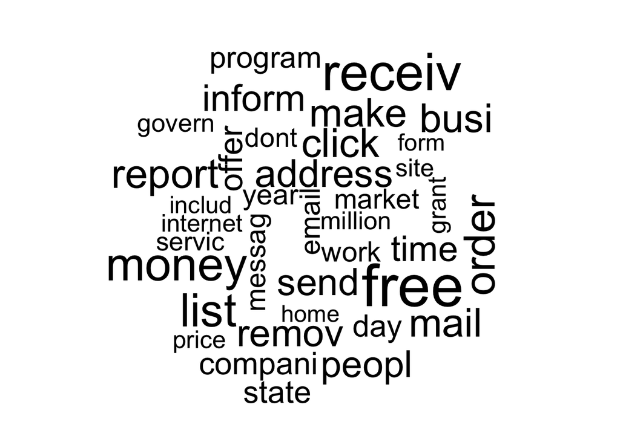

```r
spamIndex <- which( combinedDataSet$isSpam == 1 )
wordcloud( spamCorpus[spamIndex], min.freq = 200 )
```

### Create Word Cloud - Ham

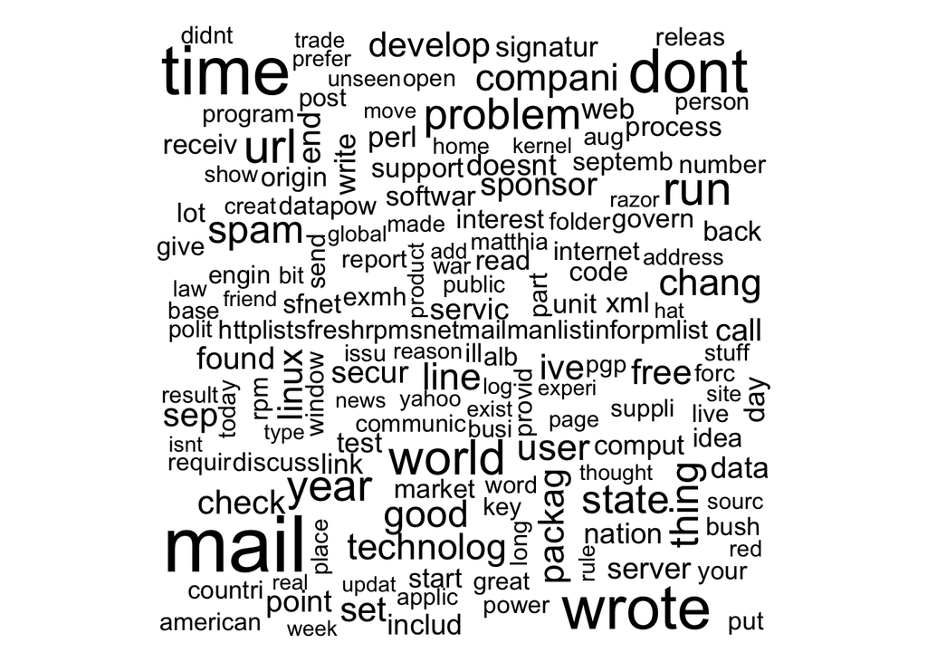

```r
spamIndex <- which( combinedDataSet$isSpam == 0 )
wordcloud( spamCorpus[spamIndex], min.freq = 200)
```

## Looking at Originating IP Address

### Obtaining IP information

I obtained the following function from the following [blog](https://heuristically.wordpress.com/2013/05/20/geolocate-ip-addresses-in-r/) post[^4]. It is a simple recursive function that takes an IP address or a vector of IP addresses and returns data about them using a JSON API for [freegeoip.app](https://freegeoip.app/).

```r
freegeoip <- function(ip, format = ifelse(length(ip)==1,'list','dataframe'))
{
    if (1 == length(ip))
    {
        # a single IP address
        require(rjson)
        url <- paste(c("https://freegeoip.app/json/", ip), collapse='')
        ret <- fromJSON(readLines(url, warn=FALSE))
        if (format == 'dataframe')
            ret <- data.frame(t(unlist(ret)))
        return(ret)
    } else {
        ret <- data.frame()
        for (i in 1:length(ip))
        {
            r <- freegeoip(ip[i], format="dataframe")
            ret <- rbind(ret, r)
        }
        return(ret)
    }
}
```

There is a limitation as to the number of queries that can be run on the API, as such I have obtained the unique IPs from the data sets, and will pass this to the `freegeoip` function above. *N.B.* The sample data consists of data from the year 2002, the API is providing current information, since then the records may have changed.

```r
uniqueIPInfo <- combinedDataSet$originatingIP %>%
  unique() %>%
  na.omit() %>%
  freegeoip()
```

I will now join the data with original data set.

```r
IPDataSet <- combinedDataSet %>%
  left_join(uniqueIPInfo, by=c("originatingIP" = "ip") )
```

Preview of Resultant data set.

```r
IPDataSet %>%
  head(30) %>%
  reactable(wrap = F)
```

| message-id | headers | body | isSpam | body_plaintext | originatingIP | country_code | country_name | region_code | region_name | city | zip_code | time_zone | latitude | longitude | metro_code |
| --- | --- | --- | --- | --- | --- | --- | --- | --- | --- | --- | --- | --- | --- | --- | --- |
| 0000.7b1b73cf36cf9dbc3d64e3f2ee2b91f1 | mv 1 00001.bfc8d64d12b325ff385cca8d07b84288 mv 10 00010.7f5fb525755c45eb78efc18d7c9ea5aa mv 100 00100.c60d1c697136b07c947fa180ba3e0441 mv 101 00101.2dfd7ee79ae439b8d9c38e783a137efa mv 102 00102.2e3969… | NA | 1 | NA | NA | NA | NA | NA | NA | NA | NA | NA | NA | NA | NA |
| 0001.bfc8d64d12b325ff385cca8d07b84288 | From 12a1mailbot1@web.de Thu Aug 22 13:17:22 2002 Return-Path: <12a1mailbot1@web.de> Delivered-To: zzzz@localhost.example.com Received: from localhost (localhost [127.0.0.1]) by phobos.labs.example.co… | <!DOCTYPE HTML PUBLIC "-//W3C//DTD HTML 4.0 Transitional//EN"> <HTML><HEAD> <META content=3D"text/html; charset=3Dwindows-1252" http-equiv=3DContent-T= ype> <META content=3D"MSHTML 5.00.2314.1000" nam… | 1 | Save up to 70% on Life Insurance. Why Spend More Than You Have To? Life Quote Savings Ensurin= g your family's financial security is very important. Life Quote Savings ma= kes buying life insurance si… | 193.120.211.219 | IE | Ireland | L | Leinster | Dublin | D02 | Europe/Dublin | 53.3338 | -6.2488 | 0 |
| 0002.24b47bb3ce90708ae29d0aec1da08610 | From ilug-admin@linux.ie Thu Aug 22 13:27:39 2002 Return-Path: <ilug-admin@linux.ie> Delivered-To: zzzz@localhost.example.com Received: from localhost (localhost [127.0.0.1]) by phobos.labs.example.co… | 1) Fight The Risk of Cancer! http://www.adclick.ws/p.cfm?o=315&s=pk007 2) Slim Down - Guaranteed to lose 10-12 lbs in 30 days http://www.adclick.ws/p.cfm?o=249&s=pk007 3) Get the Child Support You Des… | 1 | 1) Fight The Risk of Cancer! http://www.adclick.ws/p.cfm?o=315&s=pk007 2) Slim Down - Guaranteed to lose 10-12 lbs in 30 days http://www.adclick.ws/p.cfm?o=249&s=pk007 3) Get the Child Support You Des… | 194.125.145.45 | IE | Ireland | L | Leinster | Dublin | D02 | Europe/Dublin | 53.3338 | -6.2488 | 0 |
| 0003.4b3d943b8df71af248d12f8b2e7a224a | From sabrina@mx3.1premio.com Thu Aug 22 14:44:07 2002 Return-Path: <sabrina@mx3.1premio.com> Delivered-To: zzzz@localhost.example.com Received: from localhost (localhost [127.0.0.1]) by phobos.labs.ex… | 1) Fight The Risk of Cancer! http://www.adclick.ws/p.cfm?o=315&s=pk007 2) Slim Down - Guaranteed to lose 10-12 lbs in 30 days http://www.adclick.ws/p.cfm?o=249&s=pk007 3) Get the Child Support You Des… | 1 | 1) Fight The Risk of Cancer! http://www.adclick.ws/p.cfm?o=315&s=pk007 2) Slim Down - Guaranteed to lose 10-12 lbs in 30 days http://www.adclick.ws/p.cfm?o=249&s=pk007 3) Get the Child Support You Des… | 193.120.211.219 | IE | Ireland | L | Leinster | Dublin | D02 | Europe/Dublin | 53.3338 | -6.2488 | 0 |
| 0004.1874ab60c71f0b31b580f313a3f6e777 | From wsup@playful.com Thu Aug 22 16:17:00 2002 Return-Path: <wsup@playful.com> Delivered-To: zzzz@localhost.example.com Received: from localhost (localhost [127.0.0.1]) by phobos.labs.example.com (Pos… | ################################################## # # # Adult Club # # Offers FREE Membership # # # ################################################## >>>>> INSTANT ACCESS TO ALL SITES NOW >>>>> Your… | 1 | ################################################## # # # Adult Club # # Offers FREE Membership # # # ################################################## >>>>> INSTANT ACCESS TO ALL SITES NOW >>>>> Your… | 193.120.211.219 | IE | Ireland | L | Leinster | Dublin | D02 | Europe/Dublin | 53.3338 | -6.2488 | 0 |
| 0005.1f42bb885de0ef7fc5cd09d34dc2ba54 | From social-admin@linux.ie Thu Aug 22 16:37:34 2002 Return-Path: <social-admin@linux.ie> Delivered-To: zzzz@localhost.example.com Received: from localhost (localhost [127.0.0.1]) by phobos.labs.exampl… | I thought you might like these: 1) Slim Down - Guaranteed to lose 10-12 lbs in 30 days http://www.freeyankee.com/cgi/fy2/to.cgi?l=822slim1 2) Fight The Risk of Cancer! http://www.freeyankee.com/cgi/fy… | 1 | I thought you might like these: 1) Slim Down - Guaranteed to lose 10-12 lbs in 30 days http://www.freeyankee.com/cgi/fy2/to.cgi?l=822slim1 2) Fight The Risk of Cancer! http://www.freeyankee.com/cgi/fy… | 194.125.145.45 | IE | Ireland | L | Leinster | Dublin | D02 | Europe/Dublin | 53.3338 | -6.2488 | 0 |
| 0006.7a32642f8c22bbeb85d6c3b5f3890a2c | From Thecashsystem@firemail.de Thu Aug 22 16:58:24 2002 Return-Path: <Thecashsystem@firemail.de> Delivered-To: zzzz@localhost.example.com Received: from localhost (localhost [127.0.0.1]) by phobos.lab… | A POWERHOUSE GIFTING PROGRAM You Don't Want To Miss! GET IN WITH THE FOUNDERS! The MAJOR PLAYERS are on This ONE For ONCE be where the PlayerS are This is YOUR Private Invitation EXPERTS ARE CALLING T… | 1 | A POWERHOUSE GIFTING PROGRAM You Don't Want To Miss! GET IN WITH THE FOUNDERS! The MAJOR PLAYERS are on This ONE For ONCE be where the PlayerS are This is YOUR Private Invitation EXPERTS ARE CALLING T… | 193.120.211.219 | IE | Ireland | L | Leinster | Dublin | D02 | Europe/Dublin | 53.3338 | -6.2488 | 0 |
| 0007.859c901719011d56f8b652ea071c1f8b | From fort@bluemail.dk Thu Aug 22 18:28:10 2002 Return-Path: <fort@bluemail.dk> Delivered-To: zzzz@localhost.example.com Received: from localhost (localhost [127.0.0.1]) by phobos.labs.example.com (Pos… | Help wanted. We are a 14 year old fortune 500 company, that is growing at a tremendous rate. We are looking for individuals who want to work from home. This is an opportunity to make an excellent inco… | 1 | Help wanted. We are a 14 year old fortune 500 company, that is growing at a tremendous rate. We are looking for individuals who want to work from home. This is an opportunity to make an excellent inco… | 193.120.211.219 | IE | Ireland | L | Leinster | Dublin | D02 | Europe/Dublin | 53.3338 | -6.2488 | 0 |
| 0008.9562918b57e044abfbce260cc875acde | From OWNER-NOLIST-SGODAILY*JM**NETNOTEINC*-COM@SMTP1.ADMANMAIL.COM Thu Aug 22 18:28:39 2002 Return-Path: <OWNER-NOLIST-SGODAILY*JM**NETNOTEINC*-COM@SMTP1.ADMANMAIL.COM> Delivered-To: zzzz@localhost.ex… | <html> <head> <title>ReliaQuote - Save Up To 70% On Life Insurance</title> <meta http-equiv="Content-Type" content="text/html; charset=iso-8859-1"> </head> <body leftmargin="0" topmargin="0" link="#FF… | 1 | ReliaQuote - Save Up To 70% On Life Insurance &nbsp; Life can change in an instant. That's why it is so important to protect your family's financial future with sufficient life insurance coverage. Sta… | 193.120.211.219 | IE | Ireland | L | Leinster | Dublin | D02 | Europe/Dublin | 53.3338 | -6.2488 | 0 |
| 0009.c05e264fbf18783099b53dbc9a9aacda | From Thecashsystem@firemail.de Thu Aug 22 18:28:49 2002 Return-Path: <Thecashsystem@firemail.de> Delivered-To: zzzz@localhost.example.com Received: from localhost (localhost [127.0.0.1]) by phobos.lab… | TIRED OF THE BULL OUT THERE? Want To Stop Losing Money? WANT A REAL MONEY MAKER? RECEIVE $1,000-$5,000 TODAY! EXPERTS ARE CALLING THIS THE FASTEST WAY TO HUGE CASH FLOW EVER CONCEIVED! A POWERHOUSE Gi… | 1 | TIRED OF THE BULL OUT THERE? Want To Stop Losing Money? WANT A REAL MONEY MAKER? RECEIVE $1,000-$5,000 TODAY! EXPERTS ARE CALLING THIS THE FASTEST WAY TO HUGE CASH FLOW EVER CONCEIVED! A POWERHOUSE Gi… | 193.120.211.219 | IE | Ireland | L | Leinster | Dublin | D02 | Europe/Dublin | 53.3338 | -6.2488 | 0 |

[output cut: 20 more lines]

### Looking at the messages based on Location

```r
countryDataSet <- IPDataSet %>%
  dplyr::select(-`message-id`,country_name, isSpam, originatingIP) %>%
  na.omit()

countryDataSet %>%
  head(50) %>%
  reactable(wrap=F)
```

| headers | body | isSpam | body_plaintext | originatingIP | country_code | country_name | region_code | region_name | city | zip_code | time_zone | latitude | longitude | metro_code |
| --- | --- | --- | --- | --- | --- | --- | --- | --- | --- | --- | --- | --- | --- | --- |
| From 12a1mailbot1@web.de Thu Aug 22 13:17:22 2002 Return-Path: <12a1mailbot1@web.de> Delivered-To: zzzz@localhost.example.com Received: from localhost (localhost [127.0.0.1]) by phobos.labs.example.co… | <!DOCTYPE HTML PUBLIC "-//W3C//DTD HTML 4.0 Transitional//EN"> <HTML><HEAD> <META content=3D"text/html; charset=3Dwindows-1252" http-equiv=3DContent-T= ype> <META content=3D"MSHTML 5.00.2314.1000" nam… | 1 | Save up to 70% on Life Insurance. Why Spend More Than You Have To? Life Quote Savings Ensurin= g your family's financial security is very important. Life Quote Savings ma= kes buying life insurance si… | 193.120.211.219 | IE | Ireland | L | Leinster | Dublin | D02 | Europe/Dublin | 53.3338 | -6.2488 | 0 |
| From ilug-admin@linux.ie Thu Aug 22 13:27:39 2002 Return-Path: <ilug-admin@linux.ie> Delivered-To: zzzz@localhost.example.com Received: from localhost (localhost [127.0.0.1]) by phobos.labs.example.co… | 1) Fight The Risk of Cancer! http://www.adclick.ws/p.cfm?o=315&s=pk007 2) Slim Down - Guaranteed to lose 10-12 lbs in 30 days http://www.adclick.ws/p.cfm?o=249&s=pk007 3) Get the Child Support You Des… | 1 | 1) Fight The Risk of Cancer! http://www.adclick.ws/p.cfm?o=315&s=pk007 2) Slim Down - Guaranteed to lose 10-12 lbs in 30 days http://www.adclick.ws/p.cfm?o=249&s=pk007 3) Get the Child Support You Des… | 194.125.145.45 | IE | Ireland | L | Leinster | Dublin | D02 | Europe/Dublin | 53.3338 | -6.2488 | 0 |
| From sabrina@mx3.1premio.com Thu Aug 22 14:44:07 2002 Return-Path: <sabrina@mx3.1premio.com> Delivered-To: zzzz@localhost.example.com Received: from localhost (localhost [127.0.0.1]) by phobos.labs.ex… | 1) Fight The Risk of Cancer! http://www.adclick.ws/p.cfm?o=315&s=pk007 2) Slim Down - Guaranteed to lose 10-12 lbs in 30 days http://www.adclick.ws/p.cfm?o=249&s=pk007 3) Get the Child Support You Des… | 1 | 1) Fight The Risk of Cancer! http://www.adclick.ws/p.cfm?o=315&s=pk007 2) Slim Down - Guaranteed to lose 10-12 lbs in 30 days http://www.adclick.ws/p.cfm?o=249&s=pk007 3) Get the Child Support You Des… | 193.120.211.219 | IE | Ireland | L | Leinster | Dublin | D02 | Europe/Dublin | 53.3338 | -6.2488 | 0 |
| From wsup@playful.com Thu Aug 22 16:17:00 2002 Return-Path: <wsup@playful.com> Delivered-To: zzzz@localhost.example.com Received: from localhost (localhost [127.0.0.1]) by phobos.labs.example.com (Pos… | ################################################## # # # Adult Club # # Offers FREE Membership # # # ################################################## >>>>> INSTANT ACCESS TO ALL SITES NOW >>>>> Your… | 1 | ################################################## # # # Adult Club # # Offers FREE Membership # # # ################################################## >>>>> INSTANT ACCESS TO ALL SITES NOW >>>>> Your… | 193.120.211.219 | IE | Ireland | L | Leinster | Dublin | D02 | Europe/Dublin | 53.3338 | -6.2488 | 0 |
| From social-admin@linux.ie Thu Aug 22 16:37:34 2002 Return-Path: <social-admin@linux.ie> Delivered-To: zzzz@localhost.example.com Received: from localhost (localhost [127.0.0.1]) by phobos.labs.exampl… | I thought you might like these: 1) Slim Down - Guaranteed to lose 10-12 lbs in 30 days http://www.freeyankee.com/cgi/fy2/to.cgi?l=822slim1 2) Fight The Risk of Cancer! http://www.freeyankee.com/cgi/fy… | 1 | I thought you might like these: 1) Slim Down - Guaranteed to lose 10-12 lbs in 30 days http://www.freeyankee.com/cgi/fy2/to.cgi?l=822slim1 2) Fight The Risk of Cancer! http://www.freeyankee.com/cgi/fy… | 194.125.145.45 | IE | Ireland | L | Leinster | Dublin | D02 | Europe/Dublin | 53.3338 | -6.2488 | 0 |
| From Thecashsystem@firemail.de Thu Aug 22 16:58:24 2002 Return-Path: <Thecashsystem@firemail.de> Delivered-To: zzzz@localhost.example.com Received: from localhost (localhost [127.0.0.1]) by phobos.lab… | A POWERHOUSE GIFTING PROGRAM You Don't Want To Miss! GET IN WITH THE FOUNDERS! The MAJOR PLAYERS are on This ONE For ONCE be where the PlayerS are This is YOUR Private Invitation EXPERTS ARE CALLING T… | 1 | A POWERHOUSE GIFTING PROGRAM You Don't Want To Miss! GET IN WITH THE FOUNDERS! The MAJOR PLAYERS are on This ONE For ONCE be where the PlayerS are This is YOUR Private Invitation EXPERTS ARE CALLING T… | 193.120.211.219 | IE | Ireland | L | Leinster | Dublin | D02 | Europe/Dublin | 53.3338 | -6.2488 | 0 |
| From fort@bluemail.dk Thu Aug 22 18:28:10 2002 Return-Path: <fort@bluemail.dk> Delivered-To: zzzz@localhost.example.com Received: from localhost (localhost [127.0.0.1]) by phobos.labs.example.com (Pos… | Help wanted. We are a 14 year old fortune 500 company, that is growing at a tremendous rate. We are looking for individuals who want to work from home. This is an opportunity to make an excellent inco… | 1 | Help wanted. We are a 14 year old fortune 500 company, that is growing at a tremendous rate. We are looking for individuals who want to work from home. This is an opportunity to make an excellent inco… | 193.120.211.219 | IE | Ireland | L | Leinster | Dublin | D02 | Europe/Dublin | 53.3338 | -6.2488 | 0 |
| From OWNER-NOLIST-SGODAILY*JM**NETNOTEINC*-COM@SMTP1.ADMANMAIL.COM Thu Aug 22 18:28:39 2002 Return-Path: <OWNER-NOLIST-SGODAILY*JM**NETNOTEINC*-COM@SMTP1.ADMANMAIL.COM> Delivered-To: zzzz@localhost.ex… | <html> <head> <title>ReliaQuote - Save Up To 70% On Life Insurance</title> <meta http-equiv="Content-Type" content="text/html; charset=iso-8859-1"> </head> <body leftmargin="0" topmargin="0" link="#FF… | 1 | ReliaQuote - Save Up To 70% On Life Insurance &nbsp; Life can change in an instant. That's why it is so important to protect your family's financial future with sufficient life insurance coverage. Sta… | 193.120.211.219 | IE | Ireland | L | Leinster | Dublin | D02 | Europe/Dublin | 53.3338 | -6.2488 | 0 |
| From Thecashsystem@firemail.de Thu Aug 22 18:28:49 2002 Return-Path: <Thecashsystem@firemail.de> Delivered-To: zzzz@localhost.example.com Received: from localhost (localhost [127.0.0.1]) by phobos.lab… | TIRED OF THE BULL OUT THERE? Want To Stop Losing Money? WANT A REAL MONEY MAKER? RECEIVE $1,000-$5,000 TODAY! EXPERTS ARE CALLING THIS THE FASTEST WAY TO HUGE CASH FLOW EVER CONCEIVED! A POWERHOUSE Gi… | 1 | TIRED OF THE BULL OUT THERE? Want To Stop Losing Money? WANT A REAL MONEY MAKER? RECEIVE $1,000-$5,000 TODAY! EXPERTS ARE CALLING THIS THE FASTEST WAY TO HUGE CASH FLOW EVER CONCEIVED! A POWERHOUSE Gi… | 193.120.211.219 | IE | Ireland | L | Leinster | Dublin | D02 | Europe/Dublin | 53.3338 | -6.2488 | 0 |
| From suz0123893616943@yahoo.com Fri Aug 23 11:02:50 2002 Return-Path: <suz0123893616943@yahoo.com> Delivered-To: zzzz@localhost.example.com Received: from localhost (localhost [127.0.0.1]) by phobos.l… | Dear ricardo1 , <html> <body> <center> <b><font color = "red" size = "+2.5">COST EFFECTIVE Direct Email Advertising</font><br> <font color = "blue" size = "+2">Promote Your Business For As Low As </fo… | 1 | Dear ricardo1 , COST EFFECTIVE Direct Email Advertising Promote Your Business For As Low As $50 Per 1 Million Email Addresses MAXIMIZE YOUR MARKETING DOLLARS! Complete and fax this information form to… | 193.120.211.219 | IE | Ireland | L | Leinster | Dublin | D02 | Europe/Dublin | 53.3338 | -6.2488 | 0 |

[output cut: 40 more lines]

### Summary Statistics for Region

```r
library(epiDisplay)
```

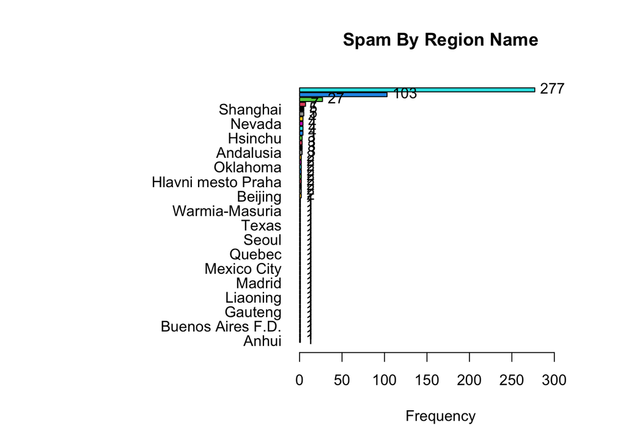

```
## spamByCountry$region_name :
##                              Frequency Percent Cum. percent
## Leinster                           277    55.4         55.4
##                                    103    20.6         76.0
## New York                            27     5.4         81.4
## Sao Paulo                            7     1.4         82.8
## Shanghai                             5     1.0         83.8
## Guangdong                            5     1.0         84.8
## Vienna                               4     0.8         85.6
## Nevada                               4     0.8         86.4
## Moscow Oblast                        4     0.8         87.2
## England                              4     0.8         88.0
## Hsinchu                              3     0.6         88.6
## Gyeonggi-do                          3     0.6         89.2
## Georgia                              3     0.6         89.8
## Andalusia                            3     0.6         90.4
## Tokyo                                2     0.4         90.8
## Shaanxi                              2     0.4         91.2
## Oklahoma                             2     0.4         91.6
## Ohio                                 2     0.4         92.0
## Île-de-France                        2     0.4         92.4
## Hlavni mesto Praha                   2     0.4         92.8
## Gyeongsangbuk-do                     2     0.4         93.2
## California                           2     0.4         93.6
## Beijing                              2     0.4         94.0
## Zarqa                                1     0.2         94.2
## Washington                           1     0.2         94.4
## Warmia-Masuria                       1     0.2         94.6
## Valais                               1     0.2         94.8
## Utah                                 1     0.2         95.0
## Texas                                1     0.2         95.2
## Tarapacá                             1     0.2         95.4
## Sham Shui Po                         1     0.2         95.6
## Seoul                                1     0.2         95.8
## Santiago Metropolitan                1     0.2         96.0
## Querétaro                            1     0.2         96.2
## Quebec                               1     0.2         96.4
## North Carolina                       1     0.2         96.6
## Minnesota                            1     0.2         96.8
## Mexico City                          1     0.2         97.0
## Massachusetts                        1     0.2         97.2
## Maharashtra                          1     0.2         97.4
## Madrid                               1     0.2         97.6
## Lower Saxony                         1     0.2         97.8
## Lombardy                             1     0.2         98.0
## Liaoning                             1     0.2         98.2
## Iowa                                 1     0.2         98.4
## Illinois                             1     0.2         98.6
## Gauteng                              1     0.2         98.8
## Fukuoka                              1     0.2         99.0
## District of Columbia                 1     0.2         99.2
## Buenos Aires F.D.                    1     0.2         99.4
## Australian Capital Territory         1     0.2         99.6
## Aragon                               1     0.2         99.8
## Anhui                                1     0.2        100.0
##   Total                            500   100.0        100.0
```

```r
spamByCountry <- countryDataSet %>%
  filter(isSpam == 1)

hamByCountry <- countryDataSet %>%
  filter(isSpam == 0)

tab1(spamByCountry$region_name, sort.group = "decreasing", cum.percent = TRUE ,main = "Spam By Region Name" )
```

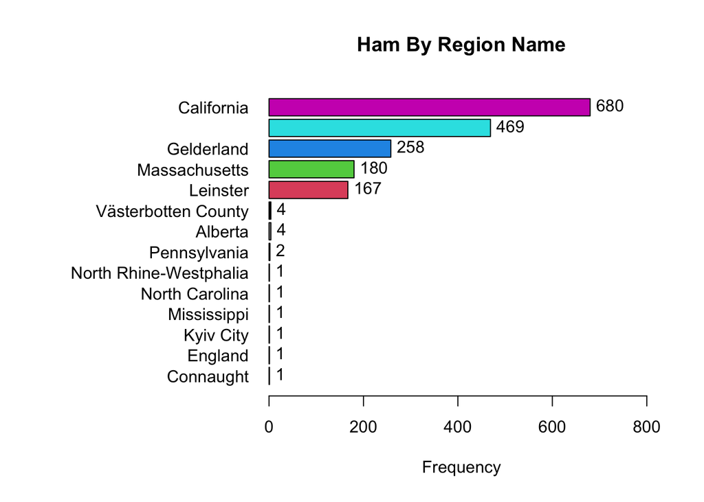

```
## hamByCountry$region_name :
##                        Frequency Percent Cum. percent
## California                   680    38.4         38.4
##                              469    26.5         64.9
## Gelderland                   258    14.6         79.5
## Massachusetts                180    10.2         89.7
## Leinster                     167     9.4         99.1
## Västerbotten County            4     0.2         99.3
## Alberta                        4     0.2         99.5
## Pennsylvania                   2     0.1         99.7
## North Rhine-Westphalia         1     0.1         99.7
## North Carolina                 1     0.1         99.8
## Mississippi                    1     0.1         99.8
## Kyiv City                      1     0.1         99.9
## England                        1     0.1         99.9
## Connaught                      1     0.1        100.0
##   Total                     1770   100.0        100.0
```

```r
tab1(hamByCountry$region_name, sort.group = "decreasing", cum.percent = TRUE ,main = "Ham By Region Name" )
```

### Summary Statistics for Country (1)

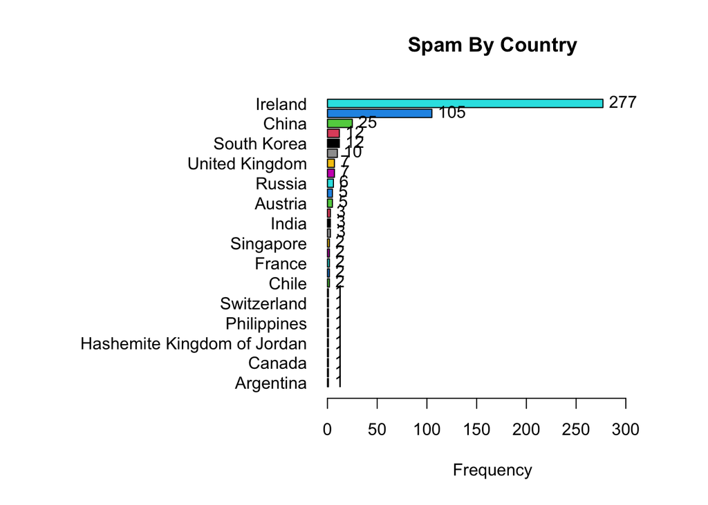

```
## spamByCountry$country_name :
##                             Frequency Percent Cum. percent
## Ireland                           277    55.4         55.4
## United States                     105    21.0         76.4
## China                              25     5.0         81.4
## Taiwan                             12     2.4         83.8
## South Korea                        12     2.4         86.2
## Spain                              10     2.0         88.2
## United Kingdom                      7     1.4         89.6
## Brazil                              7     1.4         91.0
## Russia                              6     1.2         92.2
## Japan                               5     1.0         93.2
## Austria                             5     1.0         94.2
## Mexico                              3     0.6         94.8
## India                               3     0.6         95.4
## Hong Kong                           3     0.6         96.0
## Singapore                           2     0.4         96.4
## Poland                              2     0.4         96.8
## France                              2     0.4         97.2
## Czechia                             2     0.4         97.6
## Chile                               2     0.4         98.0
## Thailand                            1     0.2         98.2
## Switzerland                         1     0.2         98.4
## South Africa                        1     0.2         98.6
## Philippines                         1     0.2         98.8
## Italy                               1     0.2         99.0
## Hashemite Kingdom of Jordan         1     0.2         99.2
## Germany                             1     0.2         99.4
## Canada                              1     0.2         99.6
## Australia                           1     0.2         99.8
## Argentina                           1     0.2        100.0
##   Total                           500   100.0        100.0
```

```r
tab1(spamByCountry$country_name, sort.group = "decreasing", cum.percent = TRUE ,main = "Spam By Country" )
```

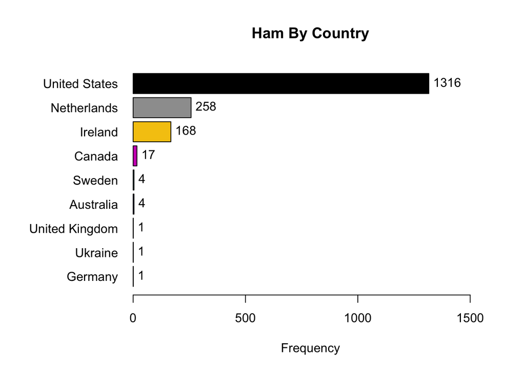

```
## hamByCountry$country_name :
##                Frequency Percent Cum. percent
## United States       1316    74.4         74.4
## Netherlands          258    14.6         88.9
## Ireland              168     9.5         98.4
## Canada                17     1.0         99.4
## Sweden                 4     0.2         99.6
## Australia              4     0.2         99.8
## United Kingdom         1     0.1         99.9
## Ukraine                1     0.1         99.9
## Germany                1     0.1        100.0
##   Total             1770   100.0        100.0
```

```r
tab1(hamByCountry$country_name, sort.group = "decreasing", cum.percent = TRUE ,main = "Ham By Country" )
```

### Summary Statistics for Country (2)

```r
tabpct(countryDataSet$country_code,countryDataSet$isSpam , xlab = "Country Code", ylab = "isSpam" , main = "Spam by Country")
```

```
##
## Original table
##                            countryDataSet$isSpam
## countryDataSet$country_code     0     1  Total
##                       AR        0     1      1
##                       AT        0     5      5
##                       AU        4     1      5
##                       BR        0     7      7
##                       CA       17     1     18
##                       CH        0     1      1
##                       CL        0     2      2
##                       CN        0    25     25
##                       CZ        0     2      2
##                       DE        1     1      2
##                       ES        0    10     10
##                       FR        0     2      2
##                       GB        1     7      8
##                       HK        0     3      3
##                       IE      168   277    445
##                       IN        0     3      3
##                       IT        0     1      1
##                       JO        0     1      1
##                       JP        0     5      5
##                       KR        0    12     12
##                       MX        0     3      3
##                       NL      258     0    258
##                       PH        0     1      1
##                       PL        0     2      2
##                       RU        0     6      6
##                       SE        4     0      4
##                       SG        0     2      2
##                       TH        0     1      1
##                       TW        0    12     12
##                       UA        1     0      1
##                       US     1316   105   1421
##                       ZA        0     1      1
##                       Total  1770   500   2270
##
## Row percent
##                            countryDataSet$isSpam
```

[output cut: 87 more lines]

```
##                       JP        0   (0.0)    5   (1.0)
##                       KR        0   (0.0)   12   (2.4)
##                       MX        0   (0.0)    3   (0.6)
##                       NL      258  (14.6)    0   (0.0)
##                       PH        0   (0.0)    1   (0.2)
##                       PL        0   (0.0)    2   (0.4)
##                       RU        0   (0.0)    6   (1.2)
##                       SE        4   (0.2)    0   (0.0)
##                       SG        0   (0.0)    2   (0.4)
##                       TH        0   (0.0)    1   (0.2)
##                       TW        0   (0.0)   12   (2.4)
##                       UA        1   (0.1)    0   (0.0)
##                       US     1316  (74.4)  105  (21.0)
##                       ZA        0   (0.0)    1   (0.2)
##                       Total  1770   (100)  500   (100)
```

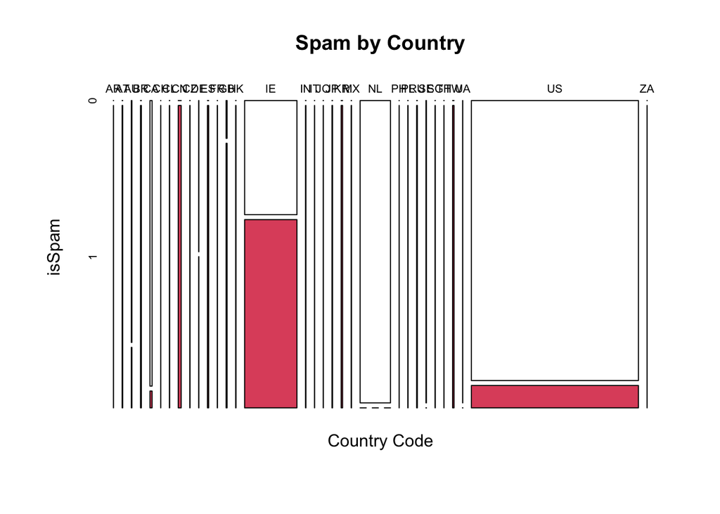

## Model Using TidyModels Package

### Load Tidymodel Package

```r
library(tidymodels)
library(textrecipes)
library(stopwords)
library(naivebayes)
library(discrim)
library(janitor)
library(kernlab)
```

### Split Data

I will begin by using the `rsample` package to split the data into a testing and training set.

```r
combinedDataSetForModel <- IPDataSet %>%
  mutate(isSpam = factor(isSpam),  originatingIP = factor(originatingIP), country_name = factor(country_name) ,region_name = factor(region_name),city = factor(city), time_zone = factor(time_zone)  ) %>%
  dplyr::select(`message-id`, isSpam, body_plaintext, originatingIP, country_name, region_name, city, time_zone)

set.seed(1234)
combinedDataSetSplit <- initial_split(combinedDataSetForModel, strata = "isSpam", p = 0.75)
train_data <- training(combinedDataSetSplit)
test_data <- testing(combinedDataSetSplit)
```

### Update Recipe

```r
spam_rec <-
  recipe(isSpam ~ . , data=train_data) %>%
  step_naomit(all_predictors()) %>%
  update_role("message-id",new_role = "ID") %>%
  step_clean_names(body_plaintext) %>%
  step_tokenize(body_plaintext) %>%
  step_stopwords(body_plaintext, keep = F) %>%
  step_stem(body_plaintext) %>%
  step_tokenfilter(body_plaintext, max_tokens = 100) %>%
  step_tfidf(body_plaintext) %>%
  prep(training = train_data)
```

### Juice the Train Data and Bake the Test Data

```r
rec_train_data <- juice(spam_rec)
rec_test_data <- bake(spam_rec, test_data)
```

### Create and Fit Model

```r
model_nb <- naive_Bayes(Laplace = 1) %>%
  set_mode("classification") %>%
  set_engine("naivebayes") %>%
  fit(isSpam ~ .,data = rec_train_data  )
```

### Verify Model Accuracy

Please see the below confusion matrix for the model.

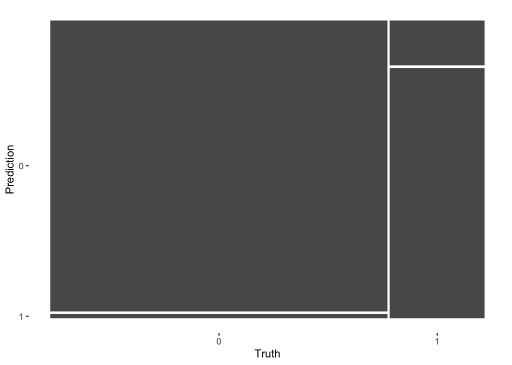

```r
testPred_nb <- model_nb %>%
  predict( rec_test_data ) %>%
  bind_cols(rec_test_data %>%
              dplyr::select(isSpam))

testPred_nb %>%
  conf_mat(isSpam, .pred_class) %>%
  autoplot()
```

Please find the accuracy for the test data below.

```r
testPred_nb %>%
  metrics(isSpam, .pred_class) %>%
  filter(.metric == "accuracy") %>%
  dplyr::select(-.estimator) %>%
  reactable()
```

| .metric | .estimate |
| --- | --- |
| accuracy | 0.956063268892794 |

## References

Costales, Bryan. 2002. “Sendmail, 3rd Edition.” *O’Reilly Online Learning*. O’Reilly Media, Inc. https://www.oreilly.com/library/view/sendmail-3rd-edition/1565928393/ch01s05.html.

Mark. 2016. “Regexp for Extracting Public IP Address.” *BigDataMark*. BigDataMark. https://www.bigdatamark.com/regexp-for-extracting-public-ip-address/.

Silge, Julia. 2020. “Sentiment Analysis with Tidymodels and #TidyTuesday Animal Crossing Reviews.” *Julia Silge*. https://juliasilge.com/blog/animal-crossing/.

The Apache Software Foundation. 2004. *Index of /Old/Publiccorpus*. The Apache Software Foundation. https://spamassassin.apache.org/old/publiccorpus/.

Ziem, Andrew. 2013. “Geolocate IP Addresses in r.” *Heuristic Andrew*. https://heuristically.wordpress.com/2013/05/20/geolocate-ip-addresses-in-r/.

[^1]: The Apache Software Foundation (2004)
[^2]: Costales (2002)
[^3]: Mark (2016)
[^4]: Ziem (2013)
[^5]: Silge (2020)